## *Sheetal Mukeshkumar Jain* **s4643507**

# Assignment 2

```r
library(readr)
thanksgiving_meals <-read_csv("https://raw.githubusercontent.com/rfordatascience/tidytuesday/master/data/2018/2018-11-20/thanksgiving_meals.csv")
```

### part 2

### **1. Display the first 10 rows of the dataset using `kable()` function (1 marks)**

```r
library(knitr)
knitr::kable(thanksgiving_meals[1:10,], "html")
```

| id | celebrate | main_dish | main_dish_other | main_prep | main_prep_other | stuffing | stuffing_other | cranberry | cranberry_other | gravy | side1 | side2 | side3 | side4 | side5 | side6 | side7 | side8 | side9 | side10 | side11 | side12 | side13 | side14 | side15 | pie1 | pie2 | pie3 | pie4 | … |
| --- | --- | --- | --- | --- | --- | --- | --- | --- | --- | --- | --- | --- | --- | --- | --- | --- | --- | --- | --- | --- | --- | --- | --- | --- | --- | --- | --- | --- | --- | --- |
| 4337954960 | Yes | Turkey | NA | Baked | NA | Bread-based | NA | None | NA | Yes | NA | Carrots | NA | NA | NA | NA | Green beans/green bean casserole | Macaroni and cheese | Mashed potatoes | NA | NA | NA | Yams/sweet potato casserole | NA | NA | Apple | NA | NA | NA | … |
| 4337951949 | Yes | Turkey | NA | Baked | NA | Bread-based | NA | Other (please specify) | Homemade cranberry gelatin ring | Yes | NA | NA | NA | Corn | NA | NA | Green beans/green bean casserole | Macaroni and cheese | Mashed potatoes | Rolls/biscuits | NA | Vegetable salad | Yams/sweet potato casserole | Other (please specify) | Asian vinagrette salad | Apple | NA | NA | Chocolate | … |
| 4337935621 | Yes | Turkey | NA | Roasted | NA | Rice-based | NA | Homemade | NA | Yes | Brussel sprouts | Carrots | Cauliflower | Corn | Cornbread | NA | NA | NA | Mashed potatoes | Rolls/biscuits | NA | Vegetable salad | NA | NA | NA | Apple | NA | Cherry | NA | … |
| 4337933040 | Yes | Turkey | NA | Baked | NA | Bread-based | NA | Homemade | NA | Yes | Brussel sprouts | NA | NA | NA | Cornbread | NA | NA | NA | Mashed potatoes | Rolls/biscuits | NA | Vegetable salad | Yams/sweet potato casserole | NA | NA | NA | NA | NA | NA | … |
| 4337931983 | Yes | Tofurkey | NA | Baked | NA | Bread-based | NA | Canned | NA | Yes | Brussel sprouts | NA | NA | NA | Cornbread | NA | NA | NA | Mashed potatoes | Rolls/biscuits | Squash | Vegetable salad | Yams/sweet potato casserole | NA | NA | Apple | NA | NA | NA | … |
| 4337929779 | Yes | Turkey | NA | Roasted | NA | Rice-based | NA | Homemade | NA | Yes | Brussel sprouts | Carrots | Cauliflower | Corn | Cornbread | Fruit salad | Green beans/green bean casserole | Macaroni and cheese | Mashed potatoes | Rolls/biscuits | Squash | Vegetable salad | Yams/sweet potato casserole | NA | NA | NA | NA | NA | NA | … |
| 4337924420 | Yes | Turkey | NA | Baked | NA | Bread-based | NA | Canned | NA | Yes | NA | NA | NA | NA | NA | Fruit salad | Green beans/green bean casserole | NA | Mashed potatoes | Rolls/biscuits | NA | NA | Yams/sweet potato casserole | NA | NA | Apple | NA | NA | NA | … |
| 4337916002 | Yes | Turkey | NA | Baked | NA | Rice-based | NA | Homemade | NA | Yes | NA | Carrots | NA | NA | NA | NA | NA | NA | NA | NA | NA | NA | NA | NA | NA | NA | NA | NA | Chocolate | … |
| 4337914977 | Yes | Turkey | NA | Roasted | NA | Bread-based | NA | Canned | NA | Yes | Brussel sprouts | NA | NA | Corn | Cornbread | NA | Green beans/green bean casserole | NA | Mashed potatoes | Rolls/biscuits | Squash | NA | NA | NA | NA | Apple | Buttermilk | NA | NA | … |
| 4337899817 | Yes | Other (please specify) | Turkey and Ham | Baked | NA | Bread-based | NA | Other (please specify) | Both Canned and Homemade | Yes | Brussel sprouts | Carrots | NA | NA | NA | NA | Green beans/green bean casserole | NA | Mashed potatoes | Rolls/biscuits | NA | NA | Yams/sweet potato casserole | NA | NA | NA | Buttermilk | NA | NA | … |

kable function displays the the observation from data frame we are working on. format, label, column name are left blank as it takes the data from table itself.

### **2. Using `skim()` display the summary of variables. Think about the task to predict a family income based on their menu: what variables may be useful? Are all of them correct type? Write 2-3 sentences with your explanation. (2 marks). Think about the task to predict a community type or US_region based on their menu: what variables may be useful? Are all of them correct type? (2 marks)**

```r
library(skimr)
skim(thanksgiving_meals)
```

Data summary

| Name | thanksgiving_meals |
| --- | --- |
| Number of rows | 1058 |
| Number of columns | 65 |
| _______________________ |  |
| Column type frequency: |  |
| character | 64 |
| numeric | 1 |
| ________________________ |  |
| Group variables | None |

**Variable type: character**

| skim_variable | n_missing | complete_rate | min | max | empty | n_unique | whitespace |
| --- | --- | --- | --- | --- | --- | --- | --- |
| celebrate | 0 | 1.00 | 2 | 3 | 0 | 2 | 0 |
| main_dish | 84 | 0.92 | 6 | 22 | 0 | 8 | 0 |
| main_dish_other | 1023 | 0.03 | 4 | 85 | 0 | 32 | 0 |
| main_prep | 84 | 0.92 | 5 | 22 | 0 | 5 | 0 |
| main_prep_other | 1007 | 0.05 | 1 | 33 | 0 | 32 | 0 |
| stuffing | 84 | 0.92 | 4 | 22 | 0 | 4 | 0 |
| stuffing_other | 1022 | 0.03 | 4 | 46 | 0 | 29 | 0 |
| cranberry | 84 | 0.92 | 4 | 22 | 0 | 4 | 0 |
| cranberry_other | 1033 | 0.02 | 3 | 61 | 0 | 24 | 0 |
| gravy | 84 | 0.92 | 2 | 3 | 0 | 2 | 0 |
| side1 | 903 | 0.15 | 15 | 15 | 0 | 1 | 0 |
| side2 | 816 | 0.23 | 7 | 7 | 0 | 1 | 0 |
| side3 | 970 | 0.08 | 11 | 11 | 0 | 1 | 0 |
| side4 | 594 | 0.44 | 4 | 4 | 0 | 1 | 0 |
| side5 | 823 | 0.22 | 9 | 9 | 0 | 1 | 0 |
| side6 | 843 | 0.20 | 11 | 11 | 0 | 1 | 0 |
| side7 | 372 | 0.65 | 32 | 32 | 0 | 1 | 0 |
| side8 | 852 | 0.19 | 19 | 19 | 0 | 1 | 0 |
| side9 | 241 | 0.77 | 15 | 15 | 0 | 1 | 0 |
| side10 | 292 | 0.72 | 14 | 14 | 0 | 1 | 0 |
| side11 | 887 | 0.16 | 6 | 6 | 0 | 1 | 0 |
| side12 | 849 | 0.20 | 15 | 15 | 0 | 1 | 0 |
| side13 | 427 | 0.60 | 27 | 27 | 0 | 1 | 0 |
| side14 | 947 | 0.10 | 22 | 22 | 0 | 1 | 0 |
| side15 | 947 | 0.10 | 4 | 78 | 0 | 89 | 0 |
| pie1 | 544 | 0.49 | 5 | 5 | 0 | 1 | 0 |
| pie2 | 1023 | 0.03 | 10 | 10 | 0 | 1 | 0 |
| pie3 | 945 | 0.11 | 6 | 6 | 0 | 1 | 0 |
| pie4 | 925 | 0.13 | 9 | 9 | 0 | 1 | 0 |
| pie5 | 1022 | 0.03 | 13 | 13 | 0 | 1 | 0 |
| pie6 | 1019 | 0.04 | 8 | 8 | 0 | 1 | 0 |
| pie7 | 1024 | 0.03 | 5 | 5 | 0 | 1 | 0 |
| pie8 | 716 | 0.32 | 5 | 5 | 0 | 1 | 0 |
| pie9 | 329 | 0.69 | 7 | 7 | 0 | 1 | 0 |
| pie10 | 906 | 0.14 | 12 | 12 | 0 | 1 | 0 |
| pie11 | 1018 | 0.04 | 4 | 4 | 0 | 1 | 0 |
| pie12 | 987 | 0.07 | 22 | 22 | 0 | 1 | 0 |
| pie13 | 987 | 0.07 | 5 | 46 | 0 | 61 | 0 |
| dessert1 | 948 | 0.10 | 13 | 13 | 0 | 1 | 0 |
| dessert2 | 1042 | 0.02 | 8 | 8 | 0 | 1 | 0 |
| dessert3 | 930 | 0.12 | 8 | 8 | 0 | 1 | 0 |
| dessert4 | 986 | 0.07 | 11 | 11 | 0 | 1 | 0 |
| dessert5 | 867 | 0.18 | 10 | 10 | 0 | 1 | 0 |
| dessert6 | 854 | 0.19 | 7 | 7 | 0 | 1 | 0 |
| dessert7 | 1015 | 0.04 | 5 | 5 | 0 | 1 | 0 |
| dessert8 | 792 | 0.25 | 9 | 9 | 0 | 1 | 0 |
| dessert9 | 955 | 0.10 | 13 | 13 | 0 | 1 | 0 |
| dessert10 | 763 | 0.28 | 4 | 4 | 0 | 1 | 0 |
| dessert11 | 924 | 0.13 | 22 | 22 | 0 | 1 | 0 |
| dessert12 | 924 | 0.13 | 3 | 59 | 0 | 92 | 0 |
| prayer | 99 | 0.91 | 2 | 3 | 0 | 2 | 0 |
| travel | 107 | 0.90 | 59 | 80 | 0 | 4 | 0 |
| watch_program | 556 | 0.47 | 13 | 13 | 0 | 1 | 0 |
| kids_table_age | 107 | 0.90 | 2 | 13 | 0 | 12 | 0 |
| hometown_friends | 107 | 0.90 | 2 | 3 | 0 | 2 | 0 |
| friendsgiving | 107 | 0.90 | 2 | 3 | 0 | 2 | 0 |
| black_friday | 107 | 0.90 | 2 | 3 | 0 | 2 | 0 |
| work_retail | 107 | 0.90 | 2 | 3 | 0 | 2 | 0 |
| work_black_friday | 988 | 0.07 | 2 | 13 | 0 | 3 | 0 |
| community_type | 110 | 0.90 | 5 | 8 | 0 | 3 | 0 |
| age | 33 | 0.97 | 3 | 7 | 0 | 4 | 0 |
| gender | 33 | 0.97 | 4 | 6 | 0 | 2 | 0 |
| family_income | 33 | 0.97 | 12 | 20 | 0 | 11 | 0 |
| us_region | 59 | 0.94 | 7 | 18 | 0 | 9 | 0 |

**Variable type: numeric**

| skim_variable | n_missing | complete_rate | mean | sd | p0 | p25 | p50 | p75 | p100 | hist |
| --- | --- | --- | --- | --- | --- | --- | --- | --- | --- | --- |
| id | 0 | 1 | 4336731188 | 493783.4 | 4335894916 | 4336339486 | 4336796628 | 4337012140 | 4337954960 | ▅▃▇▂▂ |

Us region type or community type can be predicted using variable main dish, side order, pie, dessert, gravy, and cranberry. As region of belonging have the highest impact on the food ordering behavior. All variables are character and categorical one.

### **3. Use `fct_reorder` and `parse_number` functions to create a factor variable `family_income`(2 mark).**

```r
thanksgiving_meals$familyincome1 <- ifelse(thanksgiving_meals$family_income=="Prefer not to answer", "", parse_number(thanksgiving_meals$family_income))
table(thanksgiving_meals$familyincome1)
```

```
##
##             0  10000 125000 150000 175000  1e+05  25000  2e+05  50000  75000
##    136     66     68     49     40     27    111    180     80    135    133
```

```r
thanksgiving_meals$familyincome <- parse_number(thanksgiving_meals$familyincome1)
```

### **4. What is the number of people who celebrate? (1 mark)**

The sum function will add the number of observation where family celebrate thanks giving. We are using inline command of r markdown package to calculate the number. syntex is “r sum(thanksgiving_meals$celebrate ==”Yes“)” with ` quotes in starting and ending inplace of double quote. The number of people who celebrate is 980.

### **5. What are categories and insights for each main dish served and the method it is prepared? (2 marks)**

The main dish served using various method of preparation are following:

```r
table(thanksgiving_meals$main_dish)
```

```
##
##                Chicken               Ham/Pork           I don't know
##                     12                     29                      5
## Other (please specify)             Roast beef               Tofurkey
##                     35                     11                     20
##              Turducken                 Turkey
##                      3                    859
```

```r
crosstable <- table(thanksgiving_meals$main_dish, thanksgiving_meals$main_prep)
crosstable
```

```
##
##                          Baked Fried I don't know Other (please specify)
##   Chicken                    4     2            0                      2
##   Ham/Pork                  22     0            1                      1
##   I don't know               0     1            3                      0
##   Other (please specify)    16     1            1                     12
##   Roast beef                 3     2            0                      1
##   Tofurkey                  14     0            1                      1
##   Turducken                  0     0            0                      0
##   Turkey                   422    41           11                     34
##
##                          Roasted
##   Chicken                      4
##   Ham/Pork                     5
##   I don't know                 1
##   Other (please specify)       5
##   Roast beef                   5
##   Tofurkey                     4
##   Turducken                    3
##   Turkey                     351
```

The chicken is ordered 12 number of times out of which it is baked 4 times, Fried 2 times, Roasted 4 times, and prepared using other method 2 times.similarly other variables observation is presented in above table.

### **6. Create 3 different data viz showing insights for main dish served and the method. Provide your own legend and use themes. Write 2-3 sentences with your explanation of each insight. (4 marks)**

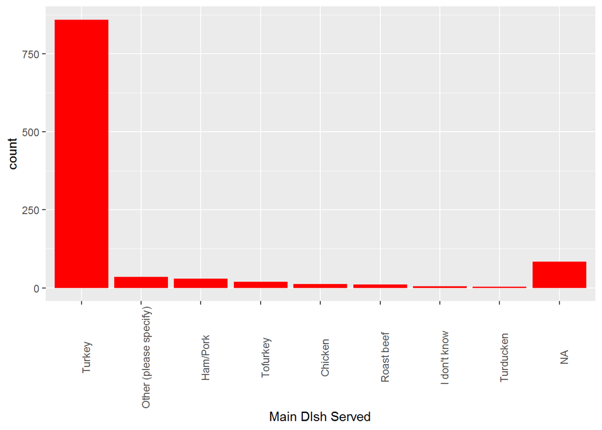

```r
library(ggplot2)
q <- ggplot(thanksgiving_meals, aes(x=reorder(thanksgiving_meals$main_dish, thanksgiving_meals$main_dish, function(x)-length(x)))) + geom_bar(fill='red') +  labs(x='Main DIsh Served')
q + theme(axis.text.x = element_text(angle = 90))
```

The bar plot shows the turkey is the highest order dish in thanksgiving dinner.

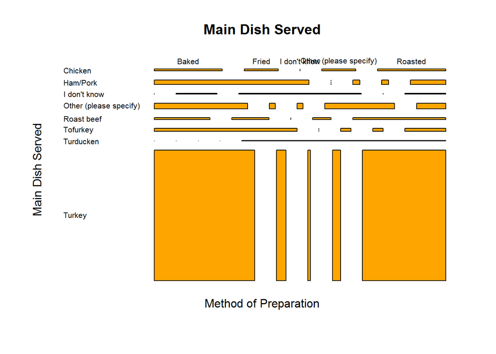

```r
counts <- table(thanksgiving_meals$main_dish, thanksgiving_meals$main_prep)
r <- mosaicplot(counts, xlab='Method of Preparation', ylab='Main Dish Served',main='Main Dish Served', col='orange',las = 1, dir = c("h", "v"),off = 30)
```

From Mosaic plot, we can conclue that Roasted Turkey, and Baked Turkey is the highest order main dish in thanks giving dinner.

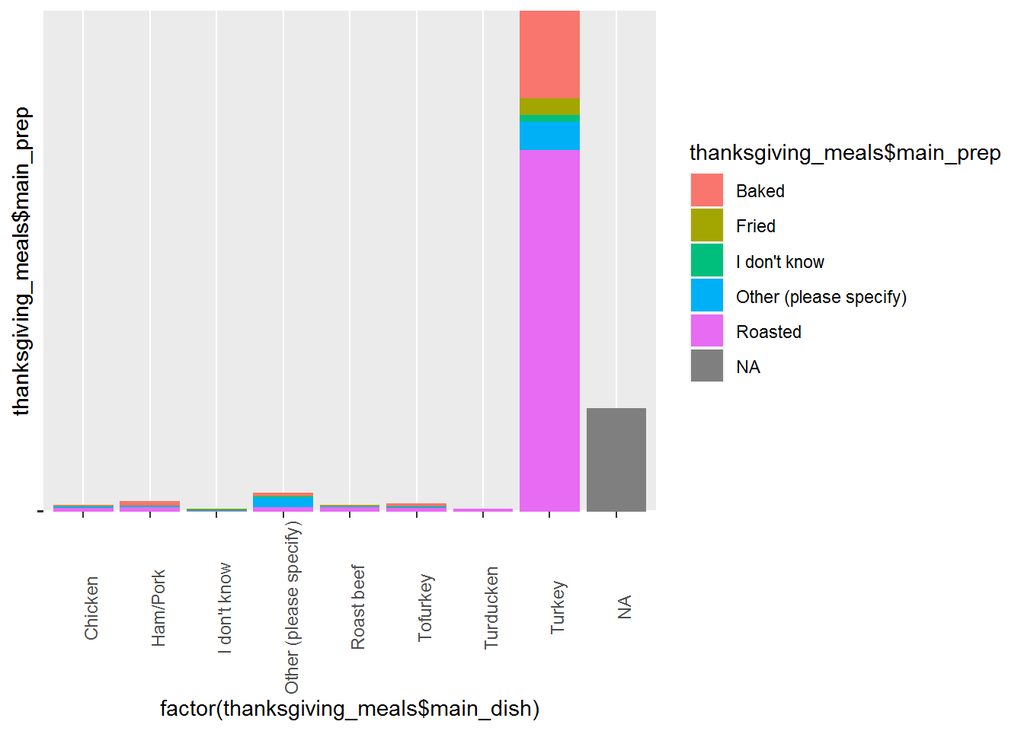

```r
library(ggplot2)
q1 <- ggplot(thanksgiving_meals, aes(x=factor(thanksgiving_meals$main_dish), y=thanksgiving_meals$main_prep, fill=thanksgiving_meals$main_prep)) + geom_bar(stat="identity")
q1+ theme(axis.text.x = element_text(angle = 90), axis.text.y = element_blank())
```

### **7. How many use cranberry sauce? How many use gravy? 2marks**

```r
table(thanksgiving_meals$cranberry)
```

```
##
##                 Canned               Homemade                   None
##                    502                    301                    146
## Other (please specify)
##                     25
```

The number of people who use Canned cranberry sauce is 502. the number of homemade cranberry sauce user is 301 while other type of sauce user are 25. total user of cranberry sauce is 828.

```r
table(thanksgiving_meals$gravy)
```

```
##
##  No Yes
##  82 892
```

The number of gravy user is 892.

### **8-9. What is the distribution of those who celebrate across income ranges. Create a data viz. Write 2-3 sentences with your explanation of each insight. (4 marks)**

```r
xx <- table(thanksgiving_meals$family_income, thanksgiving_meals$celebrate)
xx
```

```
##
##                         No Yes
##   $0 to $9,999          14  52
##   $10,000 to $24,999     8  60
##   $100,000 to $124,999   2 109
##   $125,000 to $149,999   1  48
##   $150,000 to $174,999   2  38
##   $175,000 to $199,999   1  26
##   $200,000 and up        4  76
##   $25,000 to $49,999    14 166
##   $50,000 to $74,999     8 127
##   $75,000 to $99,999     6 127
##   Prefer not to answer  18 118
```

The above table shows the number of person who celebrate in each income category. in $0 to $9999 income category 14 family not celebrated while 52 family celebrate thanksgiving. similarly we canc onclude for all the income category.

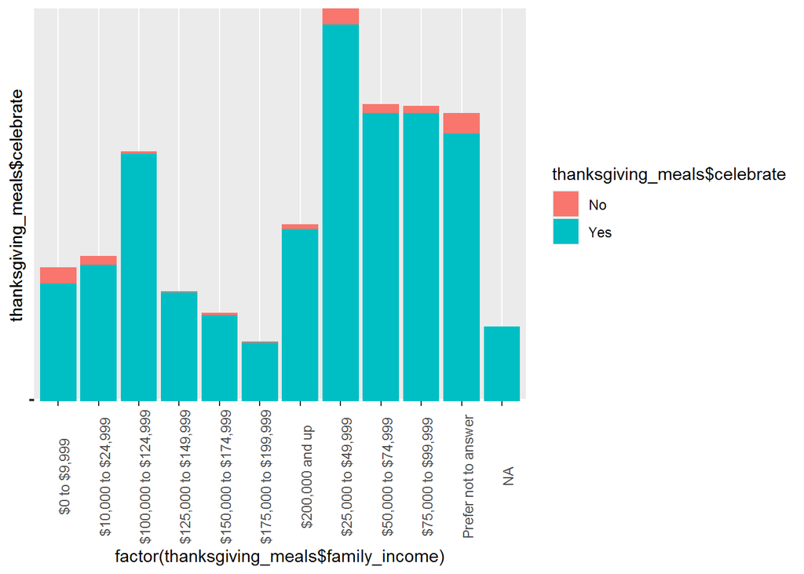

```r
library(ggplot2)
p <- ggplot(thanksgiving_meals, aes(x=factor(thanksgiving_meals$family_income), y=thanksgiving_meals$celebrate, fill=thanksgiving_meals$celebrate)) + geom_bar(stat="identity")
p+ theme(axis.text.x = element_text(angle = 90), axis.text.y = element_blank())
```

### **10. Use the following code to create a new data set 2 mark. Write 2-3 sentences with your explanation of what it does. (4 marks)**

```r
library(dplyr)
library(tidyr)
library(stringr)
newdata <- thanksgiving_meals %>% select(id, starts_with("side"), starts_with("pie"), starts_with("dessert")) %>% select(-side15, -pie13, -dessert12) %>% gather(type, value, -id) %>% filter(!is.na(value), !value %in% c("None", "Other (please specify)")) %>% mutate(type = str_remove(type, "\\d+"))

table(newdata$value)
```

```
##
##                            Apple                    Apple cobbler
##                              514                              110
##                         Blondies                         Brownies
##                               16                              128
##                  Brussel sprouts                       Buttermilk
##                              155                               35
##                      Carrot cake                          Carrots
##                               72                              242
##                      Cauliflower                       Cheesecake
##                               88                              191
##                           Cherry                        Chocolate
##                              113                              133
##                    Coconut cream                          Cookies
##                               36                              204
##                             Corn                        Cornbread
##                              464                              235
##                      Fruit salad                            Fudge
##                              215                               43
## Green beans/green bean casserole                        Ice cream
##                              686                              266
##                         Key lime              Macaroni and cheese
##                               39                              206
##                  Mashed potatoes                            Peach
##                              817                               34
##                    Peach cobbler                            Pecan
##                              103                              342
##                          Pumpkin                   Rolls/biscuits
##                              729                              766
##                           Squash                     Sweet Potato
##                              171                              152
##                  Vegetable salad      Yams/sweet potato casserole
##                              209                              631
```

```r
table(newdata$type)
```

```
##
## dessert     pie    side
##    1133    2127    4885
```

Our dataset name is newdata Select function select all the observation which have column name start with side, pie, and desert. select(-side15, -pie13, -dessert12) command drops the column with column name as side15, pie13 and desset12. gather will create a 3 variable (column) data set with 39146 observation, variable in this dataset will be id, type, and value. filter command will erase all the data with “NA”, “None”, "Other (please specify) as observation. we are left with 8145 observations. mutate drop the numeric part of dessert, pie and side from type variable.

### **11-12. Intall package `widyr` and use `pairwise_cor()` function https://www.rdocumentation.org/packages/widyr/versions/0.1.3/topics/pairwise_cor**

```r
library(widyr)
```

### Write 2-3 sentences with your explanation of what it does. (2 marks)

In particular, we compute the phi coefficient. The phi coefficient is related to the chi-squared statistic for a 2 × 2 contingency table. It states correlation among words, which indicates how often they appear together relative to how often they appear separately.

### Find correlations of pairs of items in a column, based on a “feature” column that links them together. Use this code for the new dataset

```r
pairwise_cor(newdata, value, id, sort = TRUE)
```

```
## # A tibble: 992 x 3
##    item1               item2               correlation
##    <chr>               <chr>                     <dbl>
##  1 Cookies             Brownies                  0.411
##  2 Brownies            Cookies                   0.411
##  3 Sweet Potato        Macaroni and cheese       0.365
##  4 Macaroni and cheese Sweet Potato              0.365
##  5 Rolls/biscuits      Mashed potatoes           0.341
##  6 Mashed potatoes     Rolls/biscuits            0.341
##  7 Peach cobbler       Sweet Potato              0.339
##  8 Sweet Potato        Peach cobbler             0.339
##  9 Pumpkin             Mashed potatoes           0.290
## 10 Mashed potatoes     Pumpkin                   0.290
## # ... with 982 more rows
```

### Write 1 sentence with your explanation of what insights it shows. (2 marks)

Cookies and Brownies have pair wise correlation of 0.41. Higher is the correlation value higher is chance of appearing the two strings together.

### **13. Use `lm()` or randomForest() function to build a model that predict a family income based on data in the dataset.**

```r
library(dplyr)
library(tidypredict)
modellm <- lm(formula= thanksgiving_meals$familyincome ~ factor(thanksgiving_meals$age)
           + factor(thanksgiving_meals$celebrate), data=thanksgiving_meals)
summary(modellm)
```

```
##
## Call:
## lm(formula = thanksgiving_meals$familyincome ~ factor(thanksgiving_meals$age) +
##     factor(thanksgiving_meals$celebrate), data = thanksgiving_meals)
##
## Residuals:
##    Min     1Q Median     3Q    Max
## -94510 -41181 -16181  30490 154971
##
## Coefficients:
##                                         Estimate Std. Error t value Pr(>|t|)
## (Intercept)                                25743       7940   3.242 0.001231
## factor(thanksgiving_meals$age)30 - 44      21152       5711   3.704 0.000226
## factor(thanksgiving_meals$age)45 - 59      49481       5565   8.892  < 2e-16
## factor(thanksgiving_meals$age)60+          40238       5714   7.042 3.81e-12
## factor(thanksgiving_meals$celebrate)Yes    19287       7610   2.535 0.011432
##
## (Intercept)                             **
## factor(thanksgiving_meals$age)30 - 44   ***
## factor(thanksgiving_meals$age)45 - 59   ***
## factor(thanksgiving_meals$age)60+       ***
## factor(thanksgiving_meals$celebrate)Yes *
## ---
## Signif. codes:  0 '***' 0.001 '**' 0.01 '*' 0.05 '.' 0.1 ' ' 1
##
## Residual standard error: 56240 on 884 degrees of freedom
##   (169 observations deleted due to missingness)
## Multiple R-squared:  0.1066, Adjusted R-squared:  0.1025
## F-statistic: 26.36 on 4 and 884 DF,  p-value: < 2.2e-16
```

```r
prediction <- predict(modellm, thanksgiving_meals)
summary(prediction)
```

```
##    Min. 1st Qu.  Median    Mean 3rd Qu.    Max.    NA's
##   25743   66181   85267   73076   94510   94510      33
```

Model is build using two variable age and celebrate. prediction table is created to estimate the value of family income based on the model.

### ** 8 marks Compare 3 models using different set of input variables. Use different number of variables. Explain your choice of variables (3 sentences)**

```r
reg1 <- lm(formula= thanksgiving_meals$familyincome ~ factor(thanksgiving_meals$age)
           + factor(thanksgiving_meals$gender)
           +factor(thanksgiving_meals$us_region)
           +factor(thanksgiving_meals$main_dish)
           , data=thanksgiving_meals)
summary(reg1)
```

```
##
## Call:
## lm(formula = thanksgiving_meals$familyincome ~ factor(thanksgiving_meals$age) +
##     factor(thanksgiving_meals$gender) + factor(thanksgiving_meals$us_region) +
##     factor(thanksgiving_meals$main_dish), data = thanksgiving_meals)
##
## Residuals:
##     Min      1Q  Median      3Q     Max
## -110555  -41401  -10151   29942  154465
##
## Coefficients:
##                                                            Estimate Std. Error
## (Intercept)                                                  8361.6    22553.3
## factor(thanksgiving_meals$age)30 - 44                       19466.4     6201.8
## factor(thanksgiving_meals$age)45 - 59                       48310.5     5994.2
## factor(thanksgiving_meals$age)60+                           40386.4     6063.6
## factor(thanksgiving_meals$gender)Male                        5857.4     3963.2
## factor(thanksgiving_meals$us_region)East South Central      -5175.7     9110.2
## factor(thanksgiving_meals$us_region)Middle Atlantic         16311.0     7020.3
## factor(thanksgiving_meals$us_region)Mountain                13235.0    10834.4
## factor(thanksgiving_meals$us_region)New England             13702.9     9791.6
## factor(thanksgiving_meals$us_region)Pacific                   608.3     7193.9
## factor(thanksgiving_meals$us_region)South Atlantic          -2711.8     6462.0
## factor(thanksgiving_meals$us_region)West North Central       -398.4     8805.9
## factor(thanksgiving_meals$us_region)West South Central       9354.0     8097.0
## factor(thanksgiving_meals$main_dish)Ham/Pork                26569.6    24078.0
## factor(thanksgiving_meals$main_dish)I don't know            41030.1    60196.3
## factor(thanksgiving_meals$main_dish)Other (please specify)  30608.2    23622.9
## factor(thanksgiving_meals$main_dish)Roast beef                304.0    32852.4
## factor(thanksgiving_meals$main_dish)Tofurkey                33177.3    25346.1
## factor(thanksgiving_meals$main_dish)Turducken              158175.0    45208.7
## factor(thanksgiving_meals$main_dish)Turkey                  31714.6    21382.2
##                                                            t value Pr(>|t|)
## (Intercept)                                                  0.371 0.710925
## factor(thanksgiving_meals$age)30 - 44                        3.139 0.001759 **
## factor(thanksgiving_meals$age)45 - 59                        8.060 2.81e-15 ***
## factor(thanksgiving_meals$age)60+                            6.660 5.10e-11 ***
## factor(thanksgiving_meals$gender)Male                        1.478 0.139818
## factor(thanksgiving_meals$us_region)East South Central      -0.568 0.570117
## factor(thanksgiving_meals$us_region)Middle Atlantic          2.323 0.020410 *
## factor(thanksgiving_meals$us_region)Mountain                 1.222 0.222231
## factor(thanksgiving_meals$us_region)New England              1.399 0.162067
## factor(thanksgiving_meals$us_region)Pacific                  0.085 0.932635
## factor(thanksgiving_meals$us_region)South Atlantic          -0.420 0.674854
## factor(thanksgiving_meals$us_region)West North Central      -0.045 0.963926
## factor(thanksgiving_meals$us_region)West South Central       1.155 0.248337
## factor(thanksgiving_meals$main_dish)Ham/Pork                 1.103 0.270153
## factor(thanksgiving_meals$main_dish)I don't know             0.682 0.495687
## factor(thanksgiving_meals$main_dish)Other (please specify)   1.296 0.195456
## factor(thanksgiving_meals$main_dish)Roast beef               0.009 0.992620
## factor(thanksgiving_meals$main_dish)Tofurkey                 1.309 0.190923
## factor(thanksgiving_meals$main_dish)Turducken                3.499 0.000493 ***
## factor(thanksgiving_meals$main_dish)Turkey                   1.483 0.138411
## ---
## Signif. codes:  0 '***' 0.001 '**' 0.01 '*' 0.05 '.' 0.1 ' ' 1
##
## Residual standard error: 55800 on 794 degrees of freedom
##   (244 observations deleted due to missingness)
## Multiple R-squared:  0.1229, Adjusted R-squared:  0.1019
## F-statistic: 5.857 on 19 and 794 DF,  p-value: 5.931e-14
```

```r
reg2 <- lm(formula= thanksgiving_meals$familyincome ~ factor(thanksgiving_meals$age)
           + factor(thanksgiving_meals$celebrate)
           + factor(thanksgiving_meals$gender) , data=thanksgiving_meals)
summary(reg2)
```

```
##
## Call:
## lm(formula = thanksgiving_meals$familyincome ~ factor(thanksgiving_meals$age) +
##     factor(thanksgiving_meals$celebrate) + factor(thanksgiving_meals$gender),
##     data = thanksgiving_meals)
##
## Residuals:
##    Min     1Q Median     3Q    Max
## -96709 -43070 -14221  31566 156930
##
## Coefficients:
##                                         Estimate Std. Error t value Pr(>|t|)
## (Intercept)                                23085       8292   2.784 0.005482
## factor(thanksgiving_meals$age)30 - 44      21151       5710   3.704 0.000225
## factor(thanksgiving_meals$age)45 - 59      49426       5564   8.883  < 2e-16
## factor(thanksgiving_meals$age)60+          40324       5714   7.057 3.44e-12
## factor(thanksgiving_meals$celebrate)Yes    19985       7634   2.618 0.009003
## factor(thanksgiving_meals$gender)Male       4213       3792   1.111 0.266792
##
## (Intercept)                             **
## factor(thanksgiving_meals$age)30 - 44   ***
## factor(thanksgiving_meals$age)45 - 59   ***
## factor(thanksgiving_meals$age)60+       ***
## factor(thanksgiving_meals$celebrate)Yes **
## factor(thanksgiving_meals$gender)Male
## ---
## Signif. codes:  0 '***' 0.001 '**' 0.01 '*' 0.05 '.' 0.1 ' ' 1
##
## Residual standard error: 56230 on 883 degrees of freedom
##   (169 observations deleted due to missingness)
## Multiple R-squared:  0.1078, Adjusted R-squared:  0.1028
## F-statistic: 21.34 on 5 and 883 DF,  p-value: < 2.2e-16
```

```r
reg3 <- lm(formula= thanksgiving_meals$familyincome ~ factor(thanksgiving_meals$age)
           + factor(thanksgiving_meals$celebrate), data=thanksgiving_meals)
summary(reg3)
```

```
##
## Call:
## lm(formula = thanksgiving_meals$familyincome ~ factor(thanksgiving_meals$age) +
##     factor(thanksgiving_meals$celebrate), data = thanksgiving_meals)
##
## Residuals:
##    Min     1Q Median     3Q    Max
## -94510 -41181 -16181  30490 154971
##
## Coefficients:
##                                         Estimate Std. Error t value Pr(>|t|)
## (Intercept)                                25743       7940   3.242 0.001231
## factor(thanksgiving_meals$age)30 - 44      21152       5711   3.704 0.000226
## factor(thanksgiving_meals$age)45 - 59      49481       5565   8.892  < 2e-16
## factor(thanksgiving_meals$age)60+          40238       5714   7.042 3.81e-12
## factor(thanksgiving_meals$celebrate)Yes    19287       7610   2.535 0.011432
##
## (Intercept)                             **
## factor(thanksgiving_meals$age)30 - 44   ***
## factor(thanksgiving_meals$age)45 - 59   ***
## factor(thanksgiving_meals$age)60+       ***
## factor(thanksgiving_meals$celebrate)Yes *
## ---
## Signif. codes:  0 '***' 0.001 '**' 0.01 '*' 0.05 '.' 0.1 ' ' 1
##
## Residual standard error: 56240 on 884 degrees of freedom
##   (169 observations deleted due to missingness)
## Multiple R-squared:  0.1066, Adjusted R-squared:  0.1025
## F-statistic: 26.36 on 4 and 884 DF,  p-value: < 2.2e-16
```

I have selected age, gender, celebrate, maindish and us_region as explanatory variable in our regression model.

In regression 1 model, us region and main dish variable are dropped as when dropping this, adjusted r square value increases, and maximum factor variable in us_region, and main dish category are insignificant (p value is greater than 0.1). in regression model 3, gender variable is dropped as it is insignificant in our model number 2.